# Assignment - Financial Data

## 1: Descriptive statistics and simple models

```r
#setwd("/Users/akterminsprove/Desktop/DTU/5. Semester/02418 Statistisk Modellering Teori og Anvendelser/Assignments/Financial Data")
data <- read.csv("finance_data.csv", header=TRUE,sep=";")
data$time=as.Date(data$time)
head(data,6)
```

|  | time | SLV |
| --- | --- | --- |
| 1 | 2006-05-05 | 0.013758146 |
| 2 | 2006-05-12 | 0.032857143 |
| 3 | 2006-05-19 | -0.128630705 |
| 4 | 2006-05-26 | 0.005555556 |
| 5 | 2006-06-05 | -0.045777427 |
| 6 | 2006-06-12 | -0.095119934 |

### a) Present the data, estimate the parameters in a normal model, and asses if the normal model is appropriate.

A scatter plot and a qq-plot of the data is made to asses if a normal model is appropriate.

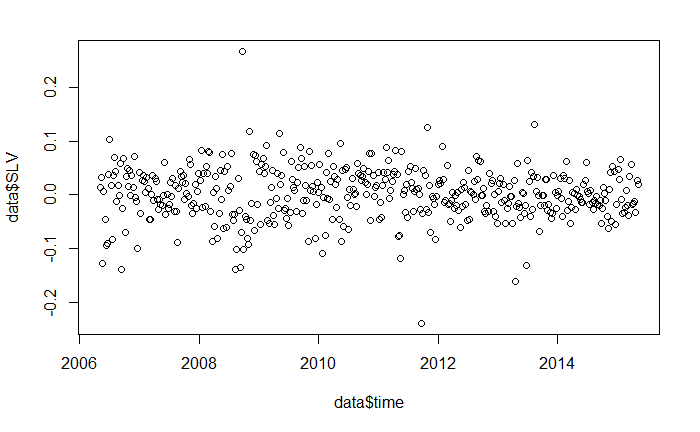

```r
plot(data$time,data$SLV)
```

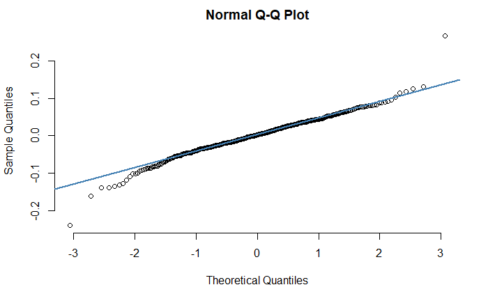

```r
qqnorm(data$SLV, pch = 1, frame = FALSE)
qqline(data$SLV, col = "steelblue", lwd = 2)
```

It seems reasonable that the data could fit a normal distribution, though some deviations at the ends.

Ignoring irrelevant constant terms the log-likelihood of a normal distribution can be formulated as:
$$l(\mu,\sigma^2)=\frac{-n}{2} log(\sigma^2)-\frac{1}{2\sigma^2}\cdot \sum_{i}(x_i-\mu)^2$$
Where the maximum likelihood estimates are:
$$\hat{\mu}= \bar{x}$$
$$\hat{\sigma^2}=\frac{1}{n}\cdot \sum_i (x_i-\bar{x})^2$$

```r
normal.function=function(dat){
normal.likelihood=function(params,dat){-sum(dnorm(x=dat,params[1],params[2],log=TRUE))}

#Find the optimal parameters using nlimnb:
opt=nlminb(c(0.001,0.001),normal.likelihood, dat=dat)
# Find the Fisher information:
H=hessian(normal.likelihood,opt$par, dat=dat)
se=sqrt(diag(solve(H)))

CI1=opt$par[1]+c(-1,1)*se[1]*qnorm(0.975)
CI2=opt$par[2]+c(-1,1)*se[2]*qnorm(0.975)

return(list("opt"=opt,"CI1"=CI1, "CI2"=CI2, "se"=se))
}


normal.function(data$SLV)
```

```
$opt
$opt$par
[1] 0.001467651 0.048254167

$opt$objective
[1] -731.9998

$opt$convergence
[1] 0

$opt$iterations
[1] 15

$opt$evaluations
function gradient
      28       38

$opt$message
[1] "relative convergence (4)"


$CI1
[1] -0.002971041  0.005906343

$CI2
[1] 0.04511554 0.05139279

$se
[1] 0.00226468 0.00160137
```

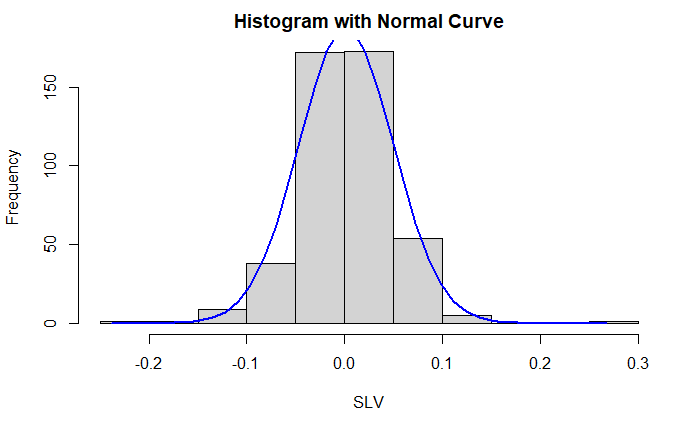

```r
x=data$SLV
h<-hist(x, xlab="SLV",
   main="Histogram with Normal Curve")
xfit<-seq(min(x),max(x),length=40)
yfit<-dnorm(xfit,normal.function(data$SLV)$opt$par[1],normal.function(data$SLV)$opt$par[2])
yfit <- yfit*diff(h$mids[1:2])*length(x)
lines(xfit, yfit, col="blue", lwd=2)
```

#### b) Hypothesize a model that could fit the data better (Hint: consider tail probabilities), and compare with the normal model estimated above

A model that considers the tail probabilities is a t-distribution with $v$ degrees of freedom, if $v=1$ we obtain the cauchy model, while $v \rightarrow \infinity$ gives the normal distribution.

```r
library(metRology)
t.function=function(dat){
t.likelihood=function(params,dat){
  -sum(dt.scaled(x=dat, df=params[1], mean = params[2], sd = params[3], log = TRUE))}


#Find the optimal parameters using nlimnb:
opt=nlminb(c(1,0.001,0.001),t.likelihood, dat=dat)
# Find the Fisher information:
H=hessian(t.likelihood,opt$par, dat=dat)
se=sqrt(diag(solve(H)))

CI1=opt$par[1]+c(-1,1)*se[1]*qnorm(0.975)
CI2=opt$par[2]+c(-1,1)*se[2]*qnorm(0.975)
CI3=opt$par[3]+c(-1,1)*se[3]*qnorm(0.975)


return(list("opt"=opt,"CI1"=CI1, "CI2"=CI2,"CI3"=CI3, "se"=se))
}

t.function(data$SLV)
```

[output not shown]

```
$opt
$opt$par
[1] 6.285876052 0.002528984 0.039499500

$opt$objective
[1] -748.1168

$opt$convergence
[1] 0

$opt$iterations
[1] 45

$opt$evaluations
function gradient
      67      158

$opt$message
[1] "relative convergence (4)"


$CI1
[1] 3.114280 9.457472

$CI2
[1] -0.001587657  0.006645625

$CI3
[1] 0.03544038 0.04355862

$se
[1] 1.618190842 0.002100366 0.002071018
```

```r
x=data$SLV
h<-hist(x, xlab="SLV",
   main="Histogram with t-curve Curve")
xfit<-seq(min(x),max(x),length=40)
yfit<-dt.scaled(xfit, df=t.function(data$SLV)$opt$par[1],mean = t.function(data$SLV)$opt$par[2],sd =t.function(data$SLV)$opt$par[3])
```

[output not shown]

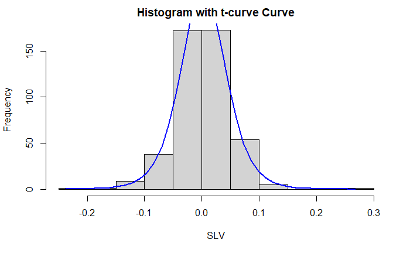

```r
yfit <- yfit*diff(h$mids[1:2])*length(x)
lines(xfit, yfit, col="blue", lwd=2)
```

#### c) represent the final model (i.e. relevant keynumbers for the estimates)

The AIC function is used to compare the two models.

```r
AIC=function(nll,k){
  2*k-2*(-nll)}
```

The table below shows the relevant key numbers for both models.

```r
library(kableExtra)
results =matrix(NA,ncol=11, nrow=2)
colnames(results) = c("","AIC", "DF", "Mean", "Sd", "CI lower DF","CI upper DF","CI lower Mean","CI upper Mean","CI lower Sd","CI upper Sd")
results[1:2,1]=c("Normal Distribution", "t - Distribution")


results[1,2] =round(AIC(normal.function(data$SLV)$opt$objective,2))
results[1,3] =NA
results[1,4] =round(normal.function(data$SLV)$opt$par[1],4)
results[1,5] =round(normal.function(data$SLV)$opt$par[2],4)
results[1,6] = NA
results[1,7] =NA
results[1,8] =round(normal.function(data$SLV)$CI1[1],4)
results[1,9] =round(normal.function(data$SLV)$CI1[2],4)
results[1,10] = round(normal.function(data$SLV)$CI2[1],4)
results[1,11] = round(normal.function(data$SLV)$CI2[2],4)

results[2,2] =round(AIC(t.function(data$SLV)$opt$objective,2))
```

[output not shown]

```r
results[2,3] =round(t.function(data$SLV)$opt$par[1],4)
```

[output not shown]

```r
results[2,4] =round(t.function(data$SLV)$opt$par[2],4)
```

[output not shown]

```r
results[2,5] =round(t.function(data$SLV)$opt$par[3],4)
```

[output not shown]

```r
results[2,6] =round(t.function(data$SLV)$CI1[1],4)
```

[output not shown]

```r
results[2,7] =round(t.function(data$SLV)$CI1[2],4)
```

[output not shown]

```r
results[2,8] =round(t.function(data$SLV)$CI2[1],4)
```

[output not shown]

```r
results[2,9] =round(t.function(data$SLV)$CI2[2],4)
```

[output not shown]

```r
results[2,10] = round(t.function(data$SLV)$CI3[1],4)
```

[output not shown]

```r
results[2,11] = round(t.function(data$SLV)$CI3[2],4)
```

[output not shown]

```r
results %>%kbl() %>%kable_styling(full_width = TRUE)
```

|  | AIC | DF | Mean | Sd | CI lower DF | CI upper DF | CI lower Mean | CI upper Mean | CI lower Sd | CI upper Sd |
| --- | --- | --- | --- | --- | --- | --- | --- | --- | --- | --- |
| Normal Distribution | -1460 | NA | 0.0015 | 0.0483 | NA | NA | -0.003 | 0.0059 | 0.0451 | 0.0514 |
| t - Distribution | -1492 | 6.2859 | 0.0025 | 0.0395 | 3.1143 | 9.4575 | -0.0016 | 0.0066 | 0.0354 | 0.0436 |